# RandomForest - 2 modalites

Random Forest est un algorithme de machine learning qui est particulièrement efficace pour repérer des liens entre une variable à expliquer et des variables explicatives. Random Forest va classer les variables explicatives en fonction de leurs liens avec la variable à expliquer

## INITIALISATION

### Installation des packages

```r
packages <- c("parallel", "pROC", "randomForest", "Epi", "doParallel", "knitr", "caret")
if (length(setdiff(packages, rownames(installed.packages()))) > 0) {
  install.packages(setdiff(packages, rownames(installed.packages())))
}
```

### Chargement des librairies

`r`r library(doParallel) library(parallel) #library(pROC) library(randomForest) library(Epi) library(knitr)

### Parallelisation des traitements

`r`r cluster <- makeCluster(detectCores() - 1) # On laisse un coeur pour l’OS

## DONNEES

### Transformation des donnees

#### Filtre (Selection des variables)

Variables a expliquer : Class_Binaire

Variables explicatives :

- Profil
- Vitesse
- Emplacement
- Age
- Type_Rayon_Courbe
- Train
- UIC
- ANNEE POSE

#### Factorisation

`r`r TAB_ECH$Class_Binaire <- as.factor(TAB_ECH$Class_Binaire) TAB_ECH$VITESSE <- as.factor(TAB_ECH$VITESSE) TAB_ECH$AGE_bis <- as.factor(TAB_ECH$AGE_bis) TAB_ECH$TR_ANNEE_POSE <- as.factor(TAB_ECH$TR_ANNEE_POSE) TAB_TEST$Class_Binaire <- as.factor(TAB_TEST$Class_Binaire) TAB_TEST$VITESSE <- as.factor(TAB_TEST$VITESSE) TAB_TEST$AGE_bis <- as.factor(TAB_TEST$AGE_bis) TAB_TEST$TR_ANNEE_POSE <- as.factor(TAB_TEST$TR_ANNEE_POSE)

## MODELISATION

### 1<sup>er</sup> modele avec le parametrage par defaut

| Parametre | Signification | Valeur |
| --- | --- | --- |
| ntree | le nombre d’arbres | 500 |
| mtry | le nombre de variables testées à chaque division | 2 |

#### Resultat du 1<sup>er</sup> modele

##### Accuracy

Precision du modele : 72.94774

`r`r (1 - BIN_RF_01$err.rate[which.min(BIN_RF_01$err.rate[,1])])*100

```
[1] 72.94774
```

##### Courbe ROC

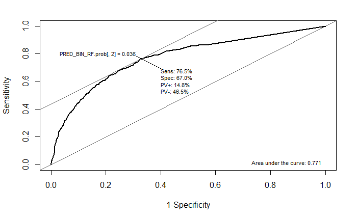

##### Matrice de confusion

`r`r # ##Matrice de confusion table(PRED_BIN_RF, TAB_TEST$Class_Binaire)

```
PRED_BIN_RF    0    1
          0 1827  613
          1  131  358
```

##### Importance des variables

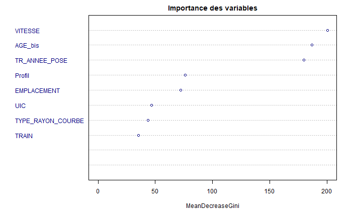

### Optimisation : recherche du nombre d’arbre optimum

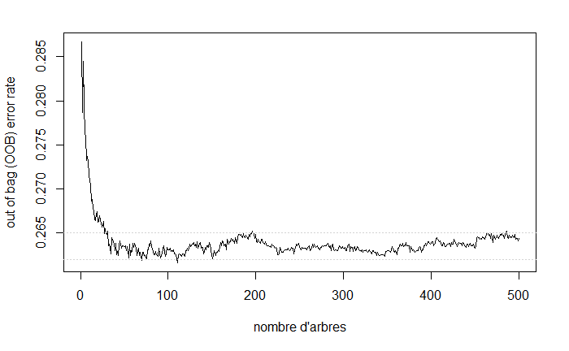

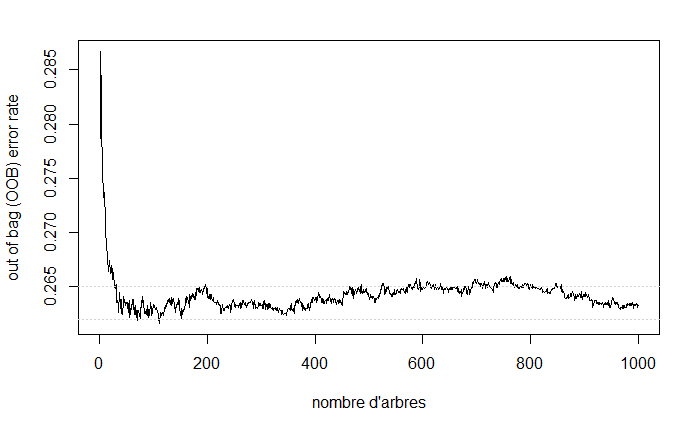

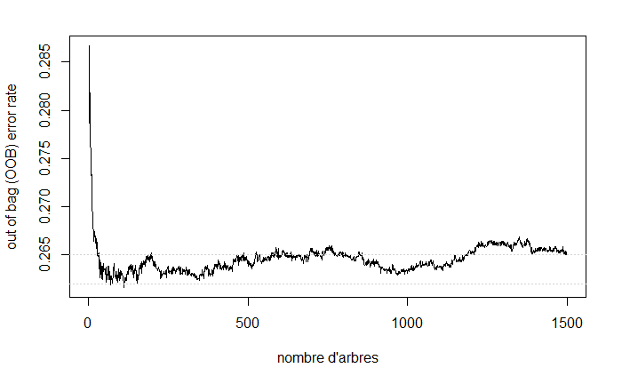

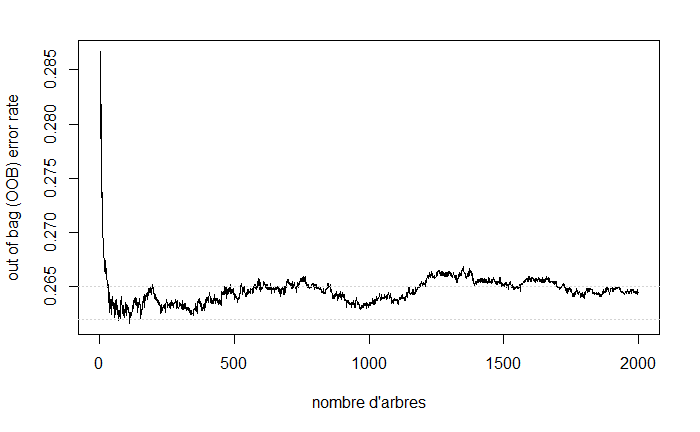

### Optimisation : le nombre de variables testées à chaque division

Utilisation de la fonction tuneRF pour determiner le mtry optimum

| parametre | signification | valeur |
| --- | --- | --- |
| ntreeTry | nombre d arbre | 350 |
| mtryStart | valeur de de depart | 2 |
| stepFactor | valeur d augmentation a chaque tour | 1.5 |
| improve | on arrete si l erreur n a pas diminue de | 0.00001 |
| trace | affiche la progression | TRUE |